# Is gesture-speech physics at work in rhythmic pointing? Evidence from Polish counting-out rhymes

Šárka Kadavá, Aleksandra Ćwiek, Katarzyna Stoltmann, Susanne Fuchs, Wim Pouw

2023-01-03

## Introduction

In this notebook we do analysis for ICPhS paper on gesture-speech physics in counting-out rhymes

## Detailed explanation of the study and the type of data and variables

Eleven native speakers (three male) of Polish were asked to perform six counting-out rhymes in two different movement conditions and one still condition. The movement conditions involved the counting-out movement with the left or the right hand, and the still condition involved reading the rhyme without any movement. All speakers were right-handed. Additionally, in the movement conditions, speakers were asked to repeat the rhyme with enhanced speed, resulting in another condition.

Altogether, these sum up to five conditions:

- left hand normal speed
- left hand fast speed
- right hand normal speed
- right hand fast speed
- reading

The order of the blocks was the same for all participants (reading, natural, fast), but the order of counting-out rhymes was randomized as well as whether they began with the dominant or non-dominant hand.

In all of those conditions, the participants performed six counting-out rhymes, the order of which was randomized across participants (cf. rhyme_order.xlsx or columns 6:11 in info.xlsx).

The participants were asked to perform each rhyme with a confederate teddy bear placed in front of them. For each condition, the participants were standing.

## Setting up the environment and packages

```r
parentfolder  <- dirname(getwd())
input_data    <- paste0(parentfolder, '/6_datasets_for_exploration_and_plots/') # folder with datasets from previous script
datasets      <- paste0(parentfolder, '/8_datasets_for_statistical_analysis/') # folder for saving datasets for statistics
plots         <- paste0(parentfolder, '/10_plots/') # folder for saving plots

# load the dataset from previous script if they are not in your environment
timeseries <- read.csv(paste0(input_data, '/dataset_ts.csv'))
#kinematics <- read.csv(paste0(input_data, '/dataset_kin.csv')) # this dataset we do not use here
#kin_finger <- read.csv(paste0(input_data, '/dataset_kin_fing.csv')) # this dataset we do not use here
kin_wrist <- read.csv(paste0(input_data, '/dataset_kin_wrist.csv'))

############# packages
library(ggplot2) # for plotting
library(ggpubr) # customizing ggplot
library(dplyr) # data wrangling
library(gridExtra) # customizing plots
library(grid) # customizing plots
library(scales) # for scaling in plotting
library(cowplot) #for nice clean graphing
library(RColorBrewer) #for coloring
```

## Data wrangling

In this analysis, we are working only with wrist markers, as we expect the wrist coordinates to have more pronounced effects

```r
### we filter the data in which peaks happen in pause, since this cannot be a real peak

kin_wrist <- subset(kin_wrist, env_syllable != '<p:>')

### Let's build the dataset we will use for statistic analysis
### We need to
 #1 filter out peaks that happens in acoustic-kinematic synchrony higher than 80 ms as we expect that only tight synchrony can lead to effects
 #2 filter out envelope amplitude peaks in which F0 is 0, as these cannot be real peaks
### We are building the datasets for each acoustic-kinematic pair

## env and acc in wrist with synchrony lower/higher than +-80
df_envacc_sync_w <- subset(kin_wrist, wrist_accenv_sync >= -80 & wrist_accenv_sync <= 80)
df_envacc_sync_w <- subset(df_envacc_sync_w, wrist_f0_accenvpeak != 0) ## put away envpeaks where f0 = 0
# you can save it
write.csv(df_envacc_sync_w, paste0(datasets, "dataset_env_acc.csv"), row.names = FALSE)

## f0 and acc in wrist with synchrony lower/higher than +-80
df_f0acc_sync_w <- subset(kin_wrist, wrist_accf0_sync >= -80 & wrist_accf0_sync <= 80)
# you can save it
write.csv(df_f0acc_sync_w, paste0(datasets, "dataset_f0_acc.csv"), row.names = FALSE)

# env and dec in wrist with synchrony lower/higher than +-80
df_envdec_sync_w <- subset(kin_wrist, wrist_decenv_sync >= -80 & wrist_decenv_sync <= 80)
df_envdec_sync_w <- subset(df_envdec_sync_w, wrist_f0_decenvpeak != 0)
# you can save it
write.csv(df_envdec_sync_w, paste0(datasets, "dataset_env_dec.csv"), row.names = FALSE)

# f0 and dec in wrist with synchrony lower/higher than +-80
df_f0dec_sync_w <- subset(kin_wrist, wrist_decf0_sync >= -80 & wrist_decf0_sync <= 80)
# you can save it
write.csv(df_f0dec_sync_w, paste0(datasets, "dataset_f0_dec.csv"), row.names = FALSE)

## Note that we do not filter out outliers before saving datasets for statistical analysis. They are removed in script with statistical analysis
```

## Data wrangling and annotation

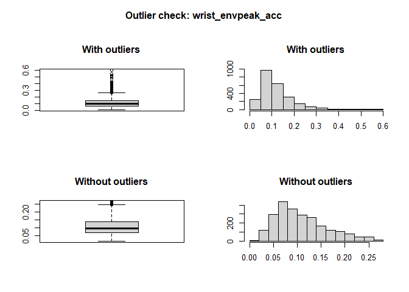

```
## Variable: wrist_envpeak_acc
## Outliers identified: 102
## Proportion (%) of outliers: 4.2
## Mean of the outliers: 0.33
## Mean with outliers: 0.12
## Mean without outliers: 0.11
```

```r
#Function adapted from: http://goo.gl/UUyEzD
# in the form of outlierKD(f0_dec, wrist_f0peak_dec)

outlierKD <- function(dt, var, group = NULL, plot = TRUE, verbose = TRUE) {
  var_chr <- deparse(substitute(var))
  x <- dt[[var_chr]]

  na1     <- sum(is.na(x))
  n_valid <- sum(!is.na(x))
  m1      <- mean(x, na.rm = TRUE)

  # flag boxplot outliers (1.5 * IQR rule), optionally within groups
  flag_out <- function(v) {
    out <- boxplot.stats(v)$out
    !is.na(v) & v %in% out
  }
  if (is.null(group)) {
    is_out <- flag_out(x)
  } else {
    is_out <- as.logical(ave(x, dt[[group]], FUN = flag_out))
  }

  x_clean <- x
  x_clean[is_out] <- NA

  if (plot) {
    op <- par(mfrow = c(2, 2), oma = c(0, 0, 3, 0))
    on.exit(par(op))
    boxplot(x, main = "With outliers")
    hist(x, main = "With outliers", xlab = NA, ylab = NA)
    boxplot(x_clean, main = "Without outliers")
    hist(x_clean, main = "Without outliers", xlab = NA, ylab = NA)
    title(paste("Outlier check:", var_chr), outer = TRUE)
  }

  if (verbose) {
    n_out <- sum(is_out)
    cat("Variable:", var_chr, if (!is.null(group)) paste0("(within ", group, ")"), "\n")
    cat("Outliers identified:", n_out, "\n")
    cat("Proportion (%) of outliers:", round(n_out / n_valid * 100, 1), "\n")
    cat("Mean of the outliers:", if (n_out > 0) round(mean(x[is_out]), 2) else NA, "\n")
    cat("Mean with outliers:", round(m1, 2), "\n")
    cat("Mean without outliers:", round(mean(x_clean, na.rm = TRUE), 2), "\n")
  }

  dt[[var_chr]] <- x_clean
  invisible(dt)
}

# We remove outliers for each dataset and both two variables under study

## ENV-ACC

df_envacc_sync_w <- outlierKD(df_envacc_sync_w, wrist_envpeak_acc)
```

```r
#Outliers identified: 102
#Propotion (%) of outliers: 4.3
#Mean of the outliers: 0.33
#Mean without removing outliers: 0.12
#Mean if we remove outliers: 0.11


df_envacc_sync_w <- outlierKD(df_envacc_sync_w, wrist_apeak)
```

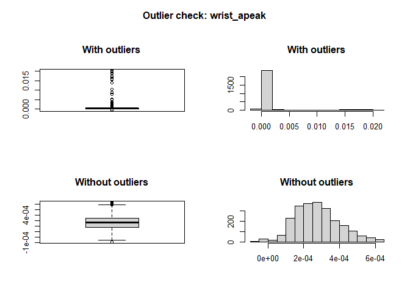

```
## Variable: wrist_apeak
## Outliers identified: 100
## Proportion (%) of outliers: 4.1
## Mean of the outliers: 0
## Mean with outliers: 0
## Mean without outliers: 0
```

```r
#Outliers identified: 100
#Propotion (%) of outliers: 4.3
#Mean of the outliers: 0
#Mean without removing outliers: 0
#Mean if we remove outliers: 0


## F0-ACC

df_f0acc_sync_w <- outlierKD(df_f0acc_sync_w, wrist_f0peak_acc)
```

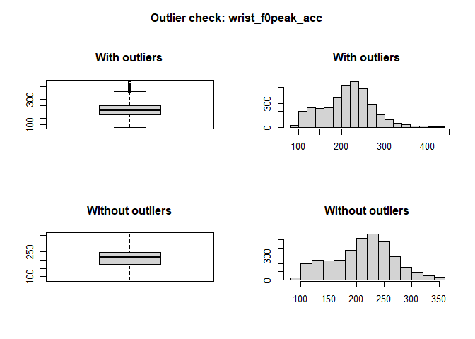

```
## Variable: wrist_f0peak_acc
## Outliers identified: 36
## Proportion (%) of outliers: 1
## Mean of the outliers: 394.95
## Mean with outliers: 213.63
## Mean without outliers: 211.79
```

```r
#Outliers identified: 36
#Propotion (%) of outliers: 1
#Mean of the outliers: 394.95
#Mean without removing outliers: 213.63
#Mean if we remove outliers: 211.79

df_f0acc_sync_w <- outlierKD(df_f0acc_sync_w, wrist_apeak)
```

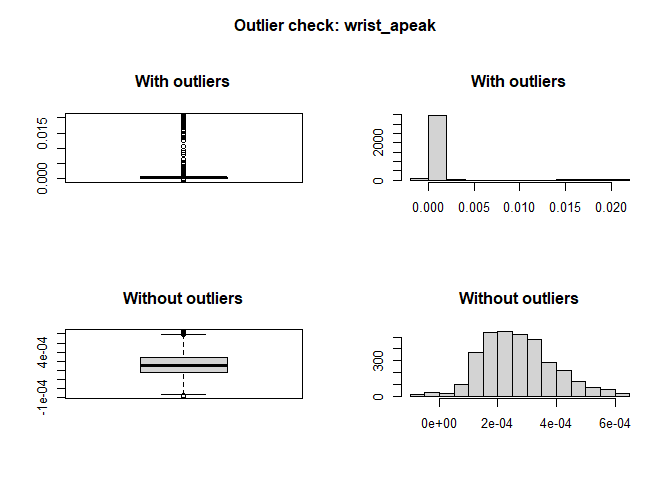

```
## Variable: wrist_apeak
## Outliers identified: 170
## Proportion (%) of outliers: 4.8
## Mean of the outliers: 0
## Mean with outliers: 0
## Mean without outliers: 0
```

```r
#Outliers identified: 170
#Propotion (%) of outliers: 5
#Mean of the outliers: 0
#Mean without removing outliers: 0
#Mean if we remove outliers: 0


## ENV-DEC

df_envdec_sync_w <- outlierKD(df_envdec_sync_w, wrist_envpeak_dec)
```

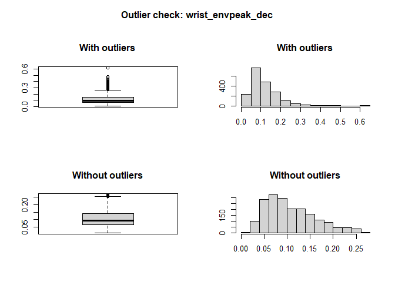

```
## Variable: wrist_envpeak_dec
## Outliers identified: 55
## Proportion (%) of outliers: 2.8
## Mean of the outliers: 0.33
## Mean with outliers: 0.11
## Mean without outliers: 0.11
```

```r
#Outliers identified: 55
#Propotion (%) of outliers: 2.9
#Mean of the outliers: 0.33
#Mean without removing outliers: 0.11
#Mean if we remove outliers: 0.11


df_envdec_sync_w <- outlierKD(df_envdec_sync_w, wrist_decpeak)
```

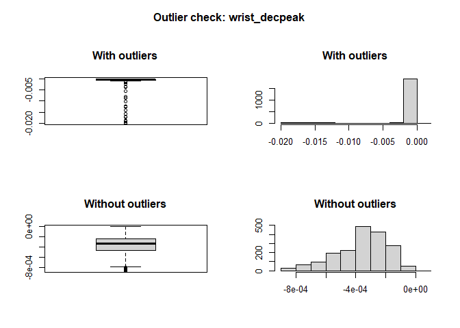

```
## Variable: wrist_decpeak
## Outliers identified: 82
## Proportion (%) of outliers: 4.2
## Mean of the outliers: 0
## Mean with outliers: 0
## Mean without outliers: 0
```

```r
#Outliers identified: 82
#Propotion (%) of outliers: 4.4
#Mean of the outliers: 0
#Mean without removing outliers: 0
#Mean if we remove outliers: 0

## F0-DEC

df_f0dec_sync_w <- outlierKD(df_f0dec_sync_w, wrist_f0peak_dec)
```

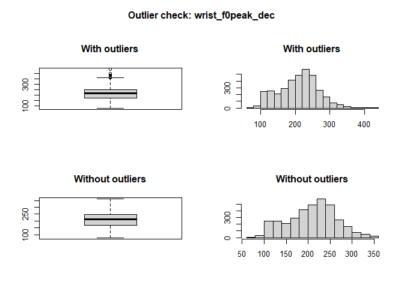

```
## Variable: wrist_f0peak_dec
## Outliers identified: 10
## Proportion (%) of outliers: 0.3
## Mean of the outliers: 378.64
## Mean with outliers: 208.98
## Mean without outliers: 208.5
```

```r
#Outliers identified: 10
#Propotion (%) of outliers: 0.3
#Mean of the outliers: 378.64
#Mean without removing outliers: 208.98
#Mean if we remove outliers: 208.5 n


df_f0dec_sync_w <- outlierKD(df_f0dec_sync_w, wrist_decpeak)
```

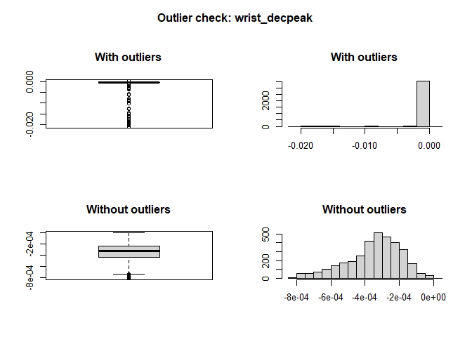

```
## Variable: wrist_decpeak
## Outliers identified: 181
## Proportion (%) of outliers: 5
## Mean of the outliers: 0
## Mean with outliers: 0
## Mean without outliers: 0
```

```r
#Outliers identified: 181
#Propotion (%) of outliers: 5.3
#Mean of the outliers: 0
#Mean without removing outliers: 0
#Mean if we remove outliers: 0 n
```

We also want to annotate the dataset with synchrony information.

```r
### if sync value is negative - kinematic peak leads the acoustic peak
### if sync value is positive - kinematic peak follows the acoustic peak
### if the sync value is between -25 and +25 - acoustic and kinematic peaks are closely synced

## ENV-ACC
df_envacc_sync_w$peak_sync <- NA
df_envacc_sync_w$peak_sync <- ifelse(df_envacc_sync_w$wrist_accenv_sync < -25, 'kpeak leads', ifelse(df_envacc_sync_w$wrist_accenv_sync >= -25 & df_envacc_sync_w$wrist_accenv_sync <= 25, 'closely synced', 'kpeak follows'))

## F0-ACC
df_f0acc_sync_w$peak_sync <- NA
df_f0acc_sync_w$peak_sync <- ifelse(df_f0acc_sync_w$wrist_accf0_sync < -25, 'kpeak leads', ifelse(df_f0acc_sync_w$wrist_accf0_sync >= -25 & df_f0acc_sync_w$wrist_accf0_sync <= 25, 'closely synced', 'kpeak follows'))

## ENV-DEC
df_envdec_sync_w$peak_sync <- NA
df_envdec_sync_w$peak_sync <- ifelse(df_envdec_sync_w$wrist_decenv_sync < -25, 'kpeak leads', ifelse(df_envdec_sync_w$wrist_decenv_sync >= -25 & df_envdec_sync_w$wrist_decenv_sync <= 25, 'closely synced', 'kpeak follows'))

## F0-DEC
df_f0dec_sync_w$peak_sync <- NA
df_f0dec_sync_w$peak_sync <- ifelse(df_f0dec_sync_w$wrist_decf0_sync < -25, 'kpeak leads', ifelse(df_f0dec_sync_w$wrist_decf0_sync >= -25 & df_f0dec_sync_w$wrist_decf0_sync <= 25, 'closely synced', 'kpeak follows'))
```

## Explorative plotting

1. Kinematic peak: acceleration

Acceleration-envelope

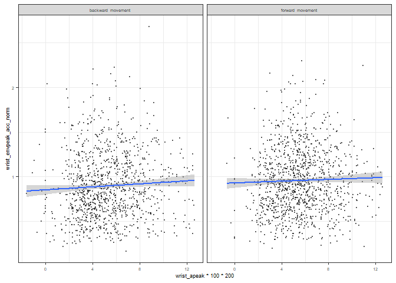

```r
# let's get a normalized amplitude envelope values
df_envacc_sync_w$wrist_envpeak_acc_norm <- NA
df_envacc_sync_w$wrist_envpeak_acc_norm <- ave(df_envacc_sync_w$wrist_envpeak_acc, df_envacc_sync_w$speaker, FUN = function(x) scale(x, center = FALSE, scale = TRUE))

# this is a basic plot exploring relationship between acceleration and amplitude envelope
# note that we multiply acceleration by *100*200 to get to cm/s^2


plot_envacc_w <- ggplot(df_envacc_sync_w, aes(x = wrist_apeak*100*200, y = wrist_envpeak_acc_norm))+
  geom_point(size = 0.5, alpha = 0.5)+
  geom_smooth(method=lm)+
  theme_bw() +
  theme(text = element_text(size = 7))

# some plots coloured by different features
## coloured by speaker
plot_envacc_w_all <- plot_envacc_w + facet_wrap(~sp_rate*speaker, ncol=11)
## coloured by rhyme
plot_envacc_w_rhyme <- plot_envacc_w + facet_wrap(~rhyme, ncol=6)
## coloured by pointing direction
plot_envacc_w_dir <- plot_envacc_w + facet_wrap(~point_direct, ncol=2)
## coloured by speech rate
plot_envacc_w_rate <- plot_envacc_w + facet_wrap(~sp_rate, ncol=2)

plot_envacc_w_dir
```

Acceleration-f0

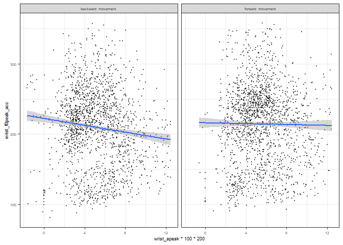

```r
# this is a basic plot exploring relationship between acceleration and f0
# note that we multiply acceleration by *100*200 to get to cm/s^2

plot_f0acc_w <- ggplot(df_f0acc_sync_w, aes(x = wrist_apeak*100*200, y = wrist_f0peak_acc))+
  geom_point(size = 0.5, alpha = 0.5)+
  geom_smooth(method=lm)+
  theme_bw() +
  theme(text = element_text(size = 7))

# some plots coloured by different features
## coloured by speaker
plot_f0cc_w_all <- plot_f0acc_w + facet_wrap(~sp_rate*speaker, ncol=11)
## coloured by rhyme
plot_f0acc_w_rhyme <- plot_f0acc_w + facet_wrap(~rhyme, ncol=6)
## coloured by pointing direction
plot_f0acc_w_dir <- plot_f0acc_w + facet_wrap(~point_direct, ncol=2)
## coloured by speech rate
plot_f0acc_w_rate <- plot_f0acc_w + facet_wrap(~sp_rate, ncol=2)

plot_f0acc_w_dir
```

2. Kinematic peak: deceleration

Deceleration-envelope - **This plot we used in the original paper**

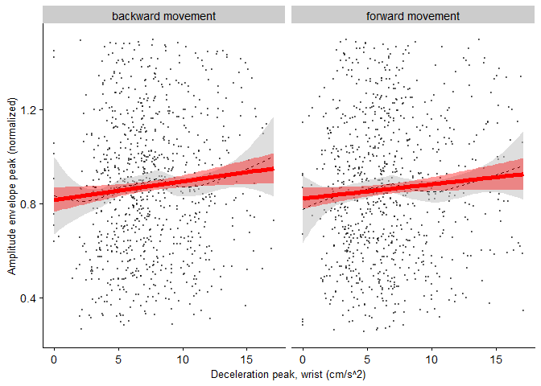

```r
# let's get a normalized amplitude envelope values
df_envdec_sync_w$wrist_envpeak_dec_norm <- NA
df_envdec_sync_w$wrist_envpeak_dec_norm <- ave(df_envdec_sync_w$wrist_envpeak_dec, df_envdec_sync_w$speaker, FUN = function(x) scale(x, center = FALSE, scale = TRUE))

## for esthetic reasons, we want to get rid of the underscore
df_envdec_sync_w$point_direct <- ifelse(df_envdec_sync_w$point_direct == 'backward_movement', 'backward movement', 'forward movement')

# this is a basic plot exploring relationship between deceleration and envelope
# note that we multiply acceleration by *100*200 to get to cm/s^2
# we use both lm and loess for capturing possible non-linearity

plot_decenv_w <- ggplot(df_envdec_sync_w, aes(x = wrist_decpeak*100*200, y = wrist_envpeak_dec_norm))+
  geom_point(size = 0.5, alpha = 0.5, color = 'black')+
  geom_smooth(method=loess, color = 'black', linetype = 'dashed', linewidth = 0.4, fill = 'gray', alpha = 0.5)+
  geom_smooth(method=lm, color = 'red', linewidth = 2, fill = 'red')+
  labs(x = "Deceleration peak, wrist (cm/s^2)", y = "Amplitude envelope peak (normalized)")+
  theme_cowplot(12)+
  scale_x_reverse(labels = abs)+
  ylim(0.25,1.5)+
  theme(title = element_text(size = 10), text = element_text(family = "times"))

# distinguishing by different feature

plot_decenv_w_all <- plot_decenv_w + facet_wrap(~sp_rate*speaker, ncol=11) # per trial
plot_decenv_w_speaker <- plot_decenv_w + facet_wrap(~speaker, ncol=6) # per speaker
plot_decenv_w_rhyme <- plot_decenv_w + facet_wrap(~rhyme, ncol=6) # per rhyme
plot_decenv_w_rate <- plot_decenv_w + facet_wrap(~sp_rate, ncol=2) # per speech rate



### this plot we use in paper
plot_decenv_w_dir <- plot_decenv_w + facet_wrap(~point_direct, ncol=2) # per movement direction

## save it
ggsave(file.path(plots, "decenv_plot.png"), dpi = 300)
ggsave(file.path(plots, "decenv_plot.jpg"), dpi = 300)

plot_decenv_w_dir
```

Deceleration-f0

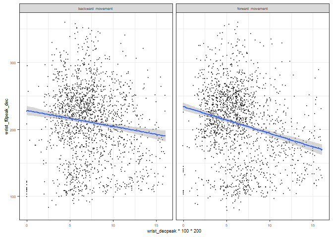

```r
# this is a basic plot exploring relationship between deceleration and f0
# note that we multiply acceleration by *100*200 to get to cm/s^2
plot_decf0_w <- ggplot(df_f0dec_sync_w, aes(x = wrist_decpeak*100*200, y = wrist_f0peak_dec))+
  geom_point(size = 0.5, alpha = 0.5)+
  geom_smooth(method=lm)+
  theme_bw() +
  theme(text = element_text(size = 7))+
  scale_x_reverse(labels = abs)

# distinguishing by different feature

plot_decf0_w_all <- plot_decf0_w + facet_wrap(~sp_rate*speaker, ncol=11) # per speaker
plot_decf0_w_rhyme <- plot_decf0_w + facet_wrap(~rhyme, ncol=6) # per rhyme
plot_decf0_w_dir <- plot_decf0_w + facet_wrap(~point_direct, ncol=2) # per pointing direction
plot_decf0_w_rate <- plot_decf0_w + facet_wrap(~sp_rate, ncol=2) # per speech rate

plot_decf0_w_dir
```

Here are all four relations in one plot

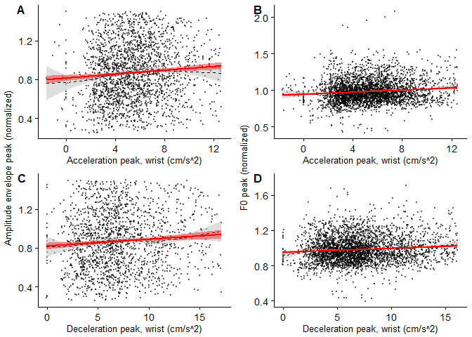

```r
# helper: publication-style plot (as in dec-env), without facetting
pub_plot <- function(data, x, y, xlab, ylab, reverse_x = FALSE, ylims = NULL) {
  p <- ggplot(data, aes(x = {{ x }} * 100 * 200, y = {{ y }})) +
    geom_point(size = 0.5, alpha = 0.5, color = "black") +
    geom_smooth(method = loess, formula = y ~ x, color = "black", linetype = "dashed",
                linewidth = 0.4, fill = "gray", alpha = 0.5) +
    geom_smooth(method = lm, formula = y ~ x, color = "red", linewidth = 1, fill = "red") +
    labs(x = xlab, y = ylab) +
    theme_cowplot(12) +
    theme(title = element_text(size = 10), text = element_text(family = "times"))
  if (reverse_x)        p <- p + scale_x_reverse(labels = abs)
  if (!is.null(ylims))  p <- p + ylim(ylims)
  p
}

# normalize f0 per speaker, same way as the envelope (see note below)
df_f0acc_sync_w$wrist_f0peak_acc_norm <- ave(df_f0acc_sync_w$wrist_f0peak_acc, df_f0acc_sync_w$speaker,
                                             FUN = function(x) scale(x, center = FALSE, scale = TRUE))
df_f0dec_sync_w$wrist_f0peak_dec_norm <- ave(df_f0dec_sync_w$wrist_f0peak_dec, df_f0dec_sync_w$speaker,
                                             FUN = function(x) scale(x, center = FALSE, scale = TRUE))

# the four panels
p_accenv <- pub_plot(df_envacc_sync_w, wrist_apeak, wrist_envpeak_acc_norm,
                     "Acceleration peak, wrist (cm/s^2)", "Amplitude envelope peak (normalized)",
                     ylims = c(0.25, 1.5))

p_accf0  <- pub_plot(df_f0acc_sync_w, wrist_apeak, wrist_f0peak_acc_norm,
                     "Acceleration peak, wrist (cm/s^2)", "F0 peak (normalized)")

p_decenv <- pub_plot(df_envdec_sync_w, wrist_decpeak, wrist_envpeak_dec_norm,
                     "Deceleration peak, wrist (cm/s^2)", "Amplitude envelope peak (normalized)",
                     reverse_x = TRUE, ylims = c(0.25, 1.5))

p_decf0  <- pub_plot(df_f0dec_sync_w, wrist_decpeak, wrist_f0peak_dec_norm,
                     "Deceleration peak, wrist (cm/s^2)", "F0 peak (normalized)",
                     reverse_x = TRUE)

# 2x2 grid with shared y-axis label per column

no_y <- theme(axis.title.y = element_blank())

# left column: envelope (A, C)
col_env <- plot_grid(p_accenv + no_y, p_decenv + no_y,
                     ncol = 1, align = "v",
                     labels = c("A", "C"), label_size = 12, label_fontfamily = "times")

# right column: f0 (B, D)
col_f0 <- plot_grid(p_accf0 + no_y, p_decf0 + no_y,
                    ncol = 1, align = "v",
                    labels = c("B", "D"), label_size = 12, label_fontfamily = "times")

# shared y-axis labels
ylab_env <- ggdraw() + draw_label("Amplitude envelope peak (normalized)",
                                  angle = 90, fontfamily = "times", size = 10)
ylab_f0  <- ggdraw() + draw_label("F0 peak (normalized)",
                                  angle = 90, fontfamily = "times", size = 10)

grid_kin <- plot_grid(ylab_env, col_env, ylab_f0, col_f0,
                      nrow = 1, rel_widths = c(0.06, 1, 0.06, 1))

# portrait format
ggsave(file.path(plots, "kinematics_grid.png"), grid_kin, width = 7, height = 9, dpi = 300)
ggsave(file.path(plots, "kinematics_grid.png"), grid_kin, width = 5, height = 7, dpi = 300)

grid_kin
```

Deceleration for f0 and env only. **This plot we use in the corrigendum**

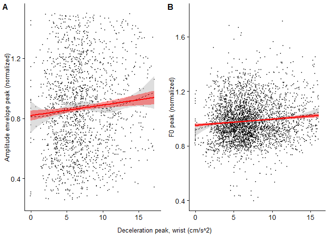

```r
no_x <- theme(axis.title.x = element_blank())

panels_dec <- plot_grid(
  p_decenv + no_x,
  p_decf0  + no_x,
  ncol = 2, align = "h",
  labels = c("A", "B"), label_size = 12, label_fontfamily = "times")

xlab_dec <- ggdraw() + draw_label("Deceleration peak, wrist (cm/s^2)",
                                  fontfamily = "times", size = 10)

grid_dec <- plot_grid(panels_dec, xlab_dec,
                      ncol = 1, rel_heights = c(1, 0.05))

ggsave(file.path(plots, "deceleration_grid.png"), grid_dec, width = 9, height = 4.5, dpi = 300)
ggsave(file.path(plots, "deceleration_grid.jpg"), grid_dec, width = 9, height = 4.5, dpi = 300)

grid_dec
```

## Plotting time series

Preparation of timeseries for plotting

```r
## normalizing the envelope
timeseries$env_norm <- ave(timeseries$env, timeseries$speaker, FUN = function(x) scale(x, center = FALSE, scale = TRUE))

# sample - ppn 5, normal speech rate, right hand, entliczek
sam <- subset(timeseries, speaker == '5' & point_hand == '_R' & rhyme_name == 'ent' & speech_rate == 'normal')
sam_peaks <- subset(kin_wrist, speaker == '5' & point_hand == '_R' & rhyme == 'ent' & sp_rate == 'normal')
```

This chunk creates plot with example of amplitude envelope, F0 and acceleration time series (first 3.4 seconds from the onset of speech). There are two plots with acceleration and 1) amplitude envelope, and 2) F0. There are also two smaller zoomed plots that introduce the peaks under study.

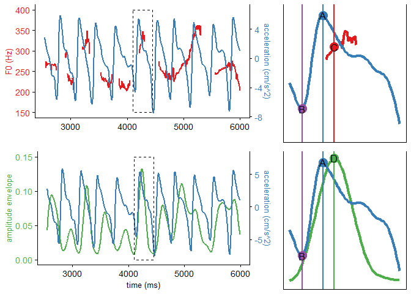

```r
beauty_colors <- brewer.pal(6, 'Set1') #produce 6 nice diverging colors

######### F0 - ACCELERATION

#let's not have 0 values in the plot, just have gaps of none-voicing
sam$f0 <- ifelse(sam$f0==0, NA, sam$f0)

# let's change unit of acceleration to cm/s^2
sam$a_wrist <- sam$a_wrist*100*200

#for setting the correct ranges to be used as a second axes
  # https://stackoverflow.com/questions/3099219/ggplot-with-2-y-axes-on-each-side-and-different-scales
ylim.f <- range(sam$f0[!is.na(sam$f0)])
ylim.a <- range(sam$a_wrist)

b <- diff(ylim.f)/diff(ylim.a ) #scaling  factor b of the differences in ranges
a <- ylim.f[1] - b*ylim.a[1]

# plotting

f0acc <- ggplot(sam, aes(x = time_ms)) +
  geom_path(aes(y = f0), color = beauty_colors[1], linewidth = 1) +
  geom_path(aes(y = a+a_wrist*b), color = beauty_colors[2], linewidth = 1.) +
  geom_rect(aes(xmin = 4100, xmax = 4450, ymin = 150, ymax = 400), color = 'black', linetype='dashed', alpha = 0)+ # for dashed-lined area that is zoomed in next plot
  theme_cowplot(12)+ scale_colour_brewer(palette = "Set1")+ theme(
    axis.title.y.left = element_text(color = beauty_colors[1]),
    axis.text.y.left = element_text(color = beauty_colors[1]),
    axis.title.y.right = element_text(color = beauty_colors[2]),
    axis.text.y.right = element_text(color = beauty_colors[2]))+
  scale_y_continuous(
    "F0 (Hz)",
    sec.axis = sec_axis(~ (. - a)/b, name = "acceleration (cm/s^2)")
  )+ labs(x = '')+
  xlim(2543,6000)+
  theme(title = element_text(size = 10), text = element_text(family = "times"))


####### ENVELOPE - ACCELERATION

#for setting the correct ranges to be used as a second axes
ylim.env <- range(sam$env)
ylim.acc <- range(sam$a_wrist)

bb <- diff(ylim.env)/diff(ylim.acc ) #scaling  factor b of the differences in ranges
aa <- ylim.env[1] - bb*ylim.acc[1]

## plotting

envacc <- ggplot(sam, aes(x = time_ms)) +
  geom_path(aes(y = env), color = beauty_colors[3], linewidth = 1) +
  geom_path(aes(y = aa+a_wrist*bb), color = beauty_colors[2], linewidth = 1.) +
  geom_rect(aes(xmin = 4100, xmax = 4450, ymin = 0, ymax = 0.15), color = 'black', linetype='dashed', alpha = 0)+ # for dashed-lined area that is zoomed in next plot
  theme_cowplot(12)+ scale_colour_brewer(palette = "Set1")+ theme(
    axis.title.y.left = element_text(color = beauty_colors[3]),
    axis.text.y.left = element_text(color = beauty_colors[3]),
    axis.title.y.right = element_text(color = beauty_colors[2]),
    axis.text.y.right = element_text(color = beauty_colors[2]))+
  scale_y_continuous(
    "amplitude envelope",
    sec.axis = sec_axis(~ (. - aa)/bb, name = "acceleration (cm/s^2)")
  ) + xlab('time (ms)')+
  xlim(2543,6000)+
  theme(title = element_text(size = 10), text = element_text(family = "times"))


## we also create plots for enlarged sections with peaks description

## xintercepts

wenv_peaks_time <- sam_peaks$wrist_envpeak_acc_time
wacc_peaks_time <- sam_peaks$wrist_apeak_time
wdec_peaks_time <- sam_peaks$wrist_decpeak_time
wacc_peaks <- sam_peaks$wrist_apeak
wf0_peaks_time <- sam_peaks$wrist_f0peak_acc_time

## F0-ACC ZOOM
### Note that xintercepts-peaks are multiplied by 100*200 to get acceleration to cm/s^2

f0acc_zoom <- ggplot(sam, aes(x = time_ms)) +
  geom_path(aes(y = f0), color = beauty_colors[1], linewidth = 1.5) +
  geom_path(aes(y = a+a_wrist*b), color = beauty_colors[2], linewidth = 1.5) +
  geom_vline(xintercept = wacc_peaks_time, color = beauty_colors[2], linetype = 'solid', linewidth = 1)+
  geom_vline(xintercept = wdec_peaks_time, color = beauty_colors[4], linetype = 'solid', linewidth = 1)+
  geom_vline(xintercept = wf0_peaks_time, color = beauty_colors[1], linetype = 'solid', linewidth = 1)+
  geom_point(data = sam_peaks, aes(x = wrist_apeak_time, y = a+wrist_apeak*b*100*200), color = beauty_colors[2], size = 5) +
  geom_text(data = sam_peaks, aes(x = wrist_apeak_time, y =  a+wrist_apeak*b*100*200, label = 'A'))+
  geom_point(data = sam_peaks, aes(x = wrist_decpeak_time, y = a+wrist_decpeak*b*100*200), color = beauty_colors[4], size = 5) +
  geom_text(data = sam_peaks, aes(x = wrist_decpeak_time, y =  a+wrist_decpeak*b*100*200, label = 'B'))+
  geom_point(data = sam_peaks, aes(x = wrist_f0peak_acc_time , y = wrist_f0peak_acc), color = beauty_colors[1], size = 5) +
  geom_text(data = sam_peaks, aes(x = wrist_f0peak_acc_time, y = wrist_f0peak_acc, label = 'C'))+
  theme_cowplot(12)+ scale_colour_brewer(palette = "Set1")+
  scale_y_continuous(
    "",
    sec.axis = sec_axis(~ (. - a)/b, name = "")
  )+ labs(x = '')+
  xlim(4100,4450)

## let's get rid of all legends and axis descriptions

f0acc_z <- f0acc_zoom +
  theme(
    axis.title.x = element_blank(),
    axis.text.x = element_blank(),
    axis.ticks.x = element_blank(),
    axis.title.y.left = element_blank(),
    axis.text.y.left = element_blank(),
    axis.ticks.y.left = element_blank(),
    axis.title.y.right = element_blank(),
    axis.text.y.right = element_blank(),
    axis.ticks.y.right = element_blank()
  )

## ENV-ACC ZOOM
### Note that xintercepts-peaks are multiplied by 100*200 to get acceleration to cm/s^2

envacc_zoom <- ggplot(sam, aes(x = time_ms)) +
  geom_path(aes(y = env), color = beauty_colors[3], linewidth = 1.5) +
  geom_path(aes(y = aa+a_wrist*bb), color = beauty_colors[2], linewidth = 1.5) +
  geom_vline(xintercept = wacc_peaks_time, color = beauty_colors[2], linetype = 'solid', linewidth = 1)+
  geom_vline(xintercept = wdec_peaks_time, color = beauty_colors[4], linetype = 'solid', linewidth = 1)+
  geom_vline(xintercept = wenv_peaks_time, color = beauty_colors[3], linetype = 'solid', linewidth = 1)+
  geom_point(data = sam_peaks, aes(x = wrist_apeak_time , y = aa+wrist_apeak*bb*100*200), color = beauty_colors[2], size = 5) +
  geom_text(data = sam_peaks, aes(x = wrist_apeak_time, y = aa+wrist_apeak*bb*100*200, label = 'A'))+
  geom_point(data = sam_peaks, aes(x = wrist_decpeak_time, y = aa+wrist_decpeak*bb*100*200), color = beauty_colors[4], size = 5) +
  geom_text(data = sam_peaks, aes(x = wrist_decpeak_time, y =  aa+wrist_decpeak*bb*100*200, label = 'B'))+
  geom_point(data = sam_peaks, aes(x = wrist_envpeak_acc_time , y = wrist_envpeak_acc), color = beauty_colors[3], size = 5) +
  geom_text(data = sam_peaks, aes(x = wrist_envpeak_acc_time, y = wrist_envpeak_acc, label = 'D'))+
  theme_cowplot(12)+ scale_colour_brewer(palette = "Set1")+ theme(
    axis.title.y.left = element_text(color = beauty_colors[3]),
    axis.text.y.left = element_text(color = beauty_colors[3]),
    axis.title.y.right = element_text(color = beauty_colors[2]),
    axis.text.y.right = element_text(color = beauty_colors[2]))+
  scale_y_continuous(
    "",
    sec.axis = sec_axis(~ (. - aa)/bb, name = "")
  ) + xlab('')+
  xlim(4100,4450)

## get rid of descriptions
envacc_z <- envacc_zoom +
  theme(
    axis.title.x = element_blank(),
    axis.text.x = element_blank(),
    axis.ticks.x = element_blank(),
    axis.title.y.left = element_blank(),
    axis.text.y.left = element_blank(),
    axis.ticks.y.left = element_blank(),
    axis.title.y.right = element_blank(),
    axis.text.y.right = element_blank(),
    axis.ticks.y.right = element_blank()
  )


## Now let's put it together

# Arrange the plots in a grid with two rows and two columns
timeseries <- grid.arrange(f0acc, f0acc_z, envacc, envacc_z,
             widths = c(0.7, 1/3))
```

```r
# save it
ggsave(file.path(plots, "timeseries.eps"), plot = timeseries, device = "eps")
```